# **Week 12. Lab 11- Advance Pandas (Questions)**

# **Assignment Submission Guidelines**

### **Steps to Submit Your Lab Assignments Using Google Colab**

1. **Submission Deadline:**
   - All assignments must be submitted **no later than 23:59 PM tonight**.
   - Late submissions will not be accepted unless prior arrangements have been made by the TAs.
2. **Complete Your Work:**
   - Finish your work in Google Colab and ensure that your notebook is saved.
3. **Submit Your Assignment on Canvas:**
   - Log in to **Canvas** and navigate to the assignment submission page.
4. **File Naming Convention:**
   - Please name your files as follows: `Lastname_Firstname_AssignmentName`
   - Example: `Alex_John_Lab10.ipynb`, `Alex_John_Lab10.pdf`
5. **Technical Issues:**
   - If you encounter any technical issues with Canvas or your submission, please contact the TAs immediately **before the deadline** to avoid penalties.

# **Questions**

## **Question 1**

**Load the Movies dataset into a pandas DataFrame and print the head of the dataset.**

```python
import pandas as pd
import matplotlib.pyplot as plt

# reading the csv.
df = pd.read_csv('Movies.csv')

# The head.
df.head()
```

|  | Film | Genre | RottenTomatoes_Ratings | Audience Ratings | Budget_m | Year_release |
| --- | --- | --- | --- | --- | --- | --- |
| 0 | (500) Days of Summer | Comedy | 87.0 | 81.0 | 8.0 | 2009.0 |
| 1 | 10,000 B.C. | Adventure | 9.0 | 44.0 | 105.0 | 2008.0 |
| 2 | 12 Rounds | Action | 30.0 | 52.0 | 20.0 | 2009.0 |
| 3 | 127 Hours | Adventure | 93.0 | 84.0 | 18.0 | 2010.0 |
| 4 | 17 Again | Comedy | 55.0 | 70.0 | 20.0 | 2009.0 |

## **Question 2**

**Find the number of rows and columns in the dataset.**

```python
print(f'rows: {df.shape[0]}, columns: {df.shape[1]}')
```

```
rows: 559, columns: 6
```

## **Question 3**

**Check for missing values in each column.**

```python
# Sum of nulls.
df.isnull().sum()
```

```
Film                       0
Genre                      2
RottenTomatoes_Ratings     8
Audience Ratings          11
Budget_m                   9
Year_release               3
dtype: int64
```

## **Question 4**

**Display basic statistics for the 'Rotten Tomatoes Ratings' and 'Budget' columns.**

```python
# Summary statistics.
df[['RottenTomatoes_Ratings', 'Budget_m']].describe()
```

|  | RottenTomatoes_Ratings | Budget_m |
| --- | --- | --- |
| count | 551.000000 | 550.000000 |
| mean | 47.477314 | 50.390909 |
| std | 26.268386 | 48.986726 |
| min | 0.000000 | 0.000000 |
| 25% | 25.500000 | 20.000000 |
| 50% | 46.000000 | 35.000000 |
| 75% | 70.000000 | 65.000000 |
| max | 97.000000 | 300.000000 |

## **Question 5**

**Create a new DataFrame containing only the films released after the year 2000.**

```python
# After 2000.
after_2000_df = df[df['Year_release'] > 2000].copy()

after_2000_df
```

|  | Film | Genre | RottenTomatoes_Ratings | Audience Ratings | Budget_m | Year_release |
| --- | --- | --- | --- | --- | --- | --- |
| 0 | (500) Days of Summer | Comedy | 87.0 | 81.0 | 8.0 | 2009.0 |
| 1 | 10,000 B.C. | Adventure | 9.0 | 44.0 | 105.0 | 2008.0 |
| 2 | 12 Rounds | Action | 30.0 | 52.0 | 20.0 | 2009.0 |
| 3 | 127 Hours | Adventure | 93.0 | 84.0 | 18.0 | 2010.0 |
| 4 | 17 Again | Comedy | 55.0 | 70.0 | 20.0 | 2009.0 |
| ... | ... | ... | ... | ... | ... | ... |
| 554 | Your Highness | Comedy | 26.0 | 36.0 | 50.0 | 2011.0 |
| 555 | Youth in Revolt | Comedy | 68.0 | 52.0 | 18.0 | 2009.0 |
| 556 | Zodiac | Thriller | 89.0 | 73.0 | 65.0 | 2007.0 |
| 557 | Zombieland | Action | 90.0 | 87.0 | 24.0 | 2009.0 |
| 558 | Zookeeper | Comedy | 14.0 | 42.0 | NaN | 2011.0 |

556 rows × 6 columns

## **Question 6**

**Filter the dataset to include only films with a budget greater than $50 million**

```python
df[df['Budget_m'] > 50]
```

|  | Film | Genre | RottenTomatoes_Ratings | Audience Ratings | Budget_m | Year_release |
| --- | --- | --- | --- | --- | --- | --- |
| 1 | 10,000 B.C. | Adventure | 9.0 | 44.0 | 105.0 | 2008.0 |
| 5 | 2012 | Action | 39.0 | 63.0 | 200.0 | 2009.0 |
| 19 | Alice in Wonderland | Adventure | 52.0 | 72.0 | 200.0 | 2010.0 |
| 25 | American Gangster | Thriller | 79.0 | 87.0 | 100.0 | 2007.0 |
| 32 | Australia | Adventure | 55.0 | 69.0 | 78.0 | 2008.0 |
| ... | ... | ... | ... | ... | ... | ... |
| 548 | Year One | Adventure | 14.0 | 31.0 | 60.0 | 2009.0 |
| 549 | Yes Man | NaN | 43.0 | 72.0 | 70.0 | NaN |
| 550 | Yogi Bear | Comedy | 14.0 | 36.0 | 80.0 | 2010.0 |
| 552 | You Don't Mess with the Zohan | Comedy | 36.0 | 50.0 | 80.0 | 2008.0 |
| 556 | Zodiac | Thriller | 89.0 | 73.0 | 65.0 | 2007.0 |

176 rows × 6 columns

## **Question 7**

**Sort the dataset by 'Rotten Tomatoes Ratings %' in descending order.**

```python
rotten_tomato_df = df.sort_values('RottenTomatoes_Ratings', ascending=False)

# Top 10 according to rotten tomatoes.
rotten_tomato_df.head(10)
```

|  | Film | Genre | RottenTomatoes_Ratings | Audience Ratings | Budget_m | Year_release |
| --- | --- | --- | --- | --- | --- | --- |
| 431 | The Hurt Locker | Drama | 97.0 | 83.0 | 15.0 | 2008.0 |
| 387 | The Artist | Drama | 97.0 | 91.0 | 16.0 | 2011.0 |
| 455 | The Muppets | Comedy | 97.0 | 87.0 | 45.0 | 2011.0 |
| 506 | True Grit | Adventure | 96.0 | 86.0 | 38.0 | 2010.0 |
| 275 | No Country for Old Men | Drama | 95.0 | 84.0 | 25.0 | 2007.0 |
| 249 | Moneyball | Drama | 95.0 | 89.0 | 50.0 | 2011.0 |
| 440 | The Kids Are All Right | Comedy | 94.0 | 72.0 | 4.0 | 2010.0 |
| 207 | Juno | Comedy | 94.0 | 89.0 | 8.0 | 2007.0 |
| 196 | Iron Man | Action | 94.0 | 91.0 | 186.0 | 2008.0 |
| 545 | Winter's Bone | Drama | 94.0 | 73.0 | 2.0 | 2010.0 |

## **Question 8**

**Sort the dataset by 'Year of release' in ascending order.**

```python
year_release_sort_df = df.sort_values('Year_release', ascending=True)

# Top 10 oldest first.
year_release_sort_df.head(10)
```

|  | Film | Genre | RottenTomatoes_Ratings | Audience Ratings | Budget_m | Year_release |
| --- | --- | --- | --- | --- | --- | --- |
| 556 | Zodiac | Thriller | 89.0 | 73.0 | 65.0 | 2007.0 |
| 20 | Alien vs. Predator -- Requiem | Horror | 14.0 | 37.0 | 40.0 | 2007.0 |
| 25 | American Gangster | Thriller | 79.0 | 87.0 | 100.0 | 2007.0 |
| 517 | Vacancy | Comedy | 55.0 | 46.0 | 19.0 | 2007.0 |
| 525 | Waitress | Romance | 89.0 | 67.0 | 2.0 | 2007.0 |
| 526 | Walk Hard: The Dewey Cox Story | Comedy | 75.0 | NaN | 35.0 | 2007.0 |
| 511 | Under the Same Moon | Drama | 72.0 | 37.0 | 2.0 | 2007.0 |
| 510 | Tyler Perry's Why Did I get Married | Romance | 46.0 | 47.0 | 15.0 | 2007.0 |
| 45 | Beowulf | Action | 71.0 | 52.0 | 150.0 | 2007.0 |
| 48 | Blades of Glory | Comedy | 69.0 | 66.0 | 61.0 | 2007.0 |

## **Question 9**

**Group the data by 'Genre' and calculate the mean 'Rotten Tomatoes Rating %' for each genre. Also, sort the Genres from highest to lowest Rotten Tomatoes Ratings**

```python
df.groupby(by='Genre')['RottenTomatoes_Ratings'].mean().sort_values(ascending=False)
```

```
Genre
Thriller     58.085714
Drama        56.180000
Adventure    53.103448
Comedy       45.734940
Romance      45.388889
Action       44.588235
Horror       35.020833
Name: RottenTomatoes_Ratings, dtype: float64
```

## **Question 10**

**Calculate the average budget for films released in each year**

```python
avg_budget_arr = df.groupby(by='Year_release')['Budget_m'].mean()
avg_budget_arr
```

```
Year_release
2007.0    58.714286
2008.0    46.905983
2009.0    48.587719
2010.0    50.598291
2011.0    50.221311
Name: Budget_m, dtype: float64
```

## **Question 11**

**Create a bar chart to show the average 'Rotten Tomatoes Ratings %' for each genre.**

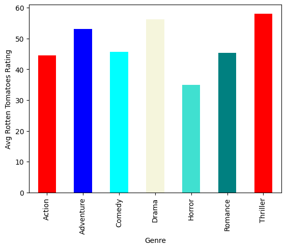

```python
new_df = df.groupby('Genre')['RottenTomatoes_Ratings'].mean()

color_list = ['red', 'blue', 'cyan', 'beige', 'turquoise', 'teal'] # The ugliest colors I could put together.

new_df.plot(kind='bar', color=color_list)

plt.xlabel('Genre')
plt.ylabel('Avg Rotten Tomatoes Rating')
```

## **Question 12**

**Replace any missing values in the 'Budget (million $)' column with the mean budget of the dataset**

```python
# The mean
mean_budget = df['Budget_m'].mean()

# Filling with the mean.
df['Budget_m'] = df['Budget_m'].fillna(mean_budget)

df.head()
```

|  | Film | Genre | RottenTomatoes_Ratings | Audience Ratings | Budget_m | Year_release |
| --- | --- | --- | --- | --- | --- | --- |
| 0 | (500) Days of Summer | Comedy | 87.0 | 81.0 | 8.0 | 2009.0 |
| 1 | 10,000 B.C. | Adventure | 9.0 | 44.0 | 105.0 | 2008.0 |
| 2 | 12 Rounds | Action | 30.0 | 52.0 | 20.0 | 2009.0 |
| 3 | 127 Hours | Adventure | 93.0 | 84.0 | 18.0 | 2010.0 |
| 4 | 17 Again | Comedy | 55.0 | 70.0 | 20.0 | 2009.0 |

## **Question 13**

**Convert the 'Year of release' column to a datetime format.**

```python
df['Year_release'] = pd.to_datetime(df['Year_release'], format='%Y')

df.head()
```

|  | Film | Genre | RottenTomatoes_Ratings | Audience Ratings | Budget_m | Year_release |
| --- | --- | --- | --- | --- | --- | --- |
| 0 | (500) Days of Summer | Comedy | 87.0 | 81.0 | 8.0 | 2009-01-01 |
| 1 | 10,000 B.C. | Adventure | 9.0 | 44.0 | 105.0 | 2008-01-01 |
| 2 | 12 Rounds | Action | 30.0 | 52.0 | 20.0 | 2009-01-01 |
| 3 | 127 Hours | Adventure | 93.0 | 84.0 | 18.0 | 2010-01-01 |
| 4 | 17 Again | Comedy | 55.0 | 70.0 | 20.0 | 2009-01-01 |

## **Question 14**

**Write code to perform mean imputation for missing values in the 'Audience Ratings' column**

```python
# Same process as the other question.
mean_audience = df['Audience Ratings'].mean()

df['Audience Ratings'] = df['Audience Ratings'].fillna(mean_audience)

df.head()
```

|  | Film | Genre | RottenTomatoes_Ratings | Audience Ratings | Budget_m | Year_release |
| --- | --- | --- | --- | --- | --- | --- |
| 0 | (500) Days of Summer | Comedy | 87.0 | 81.0 | 8.0 | 2009-01-01 |
| 1 | 10,000 B.C. | Adventure | 9.0 | 44.0 | 105.0 | 2008-01-01 |
| 2 | 12 Rounds | Action | 30.0 | 52.0 | 20.0 | 2009-01-01 |
| 3 | 127 Hours | Adventure | 93.0 | 84.0 | 18.0 | 2010-01-01 |
| 4 | 17 Again | Comedy | 55.0 | 70.0 | 20.0 | 2009-01-01 |

## **Question 15**

**Create a DataFrame that contains only movies in the 'Action' genre that have a 'RottenTomatoes_Ratings' greater than 80. How many movies are there in this filtered DataFrame?**

```python
good_action_df = df[(df['Genre'] == 'Action') & (df['RottenTomatoes_Ratings'] > 80)]

display(good_action_df)

print(f'There are {good_action_df.shape[0]} good action movies.')
```

|  | Film | Genre | RottenTomatoes_Ratings | Audience Ratings | Budget_m | Year_release |
| --- | --- | --- | --- | --- | --- | --- |
| 33 | Avatar | Action | 83.0 | 92.0 | 237.0 | 2009-01-01 |
| 94 | District 9 | Action | 91.0 | 81.0 | 30.0 | 2009-01-01 |
| 155 | Grindhouse | Action | 82.0 | 86.0 | 53.0 | 2007-01-01 |
| 170 | Hellboy II: The Golden Army | Action | 87.0 | 70.0 | 83.0 | 2008-01-01 |
| 190 | Inception | Action | 86.0 | 93.0 | 160.0 | 2010-01-01 |
| 196 | Iron Man | Action | 94.0 | 91.0 | 186.0 | 2008-01-01 |
| 248 | Mission Impossible 4 | Action | 93.0 | 86.0 | 145.0 | 2011-01-01 |
| 326 | Rise of the Planet of the Apes | Action | 83.0 | 87.0 | 93.0 | 2011-01-01 |
| 334 | Scott Pilgrim vs. the World | Action | 81.0 | 83.0 | 60.0 | 2010-01-01 |
| 362 | Star Trek | Action | 94.0 | 91.0 | 140.0 | 2009-01-01 |
| 514 | Unstoppable | Action | 86.0 | 73.0 | 95.0 | 2010-01-01 |
| 530 | Warrior | Action | 83.0 | 93.0 | 25.0 | 2011-01-01 |
| 547 | X-Men: First Class | Action | 87.0 | 88.0 | 160.0 | 2011-01-01 |
| 557 | Zombieland | Action | 90.0 | 87.0 | 24.0 | 2009-01-01 |

```
There are 14 good action movies.
```

## **Question 16**

**Group the movies by 'Year_release' and find the average 'Budget_m' for each year. Return a DataFrame of the years and their corresponding average budgets.**

```python
year_budget_group = df.groupby('Year_release')['Budget_m'].mean()

year_budget_group
```

```
Year_release
2007-01-01    58.607576
2008-01-01    46.993106
2009-01-01    48.618809
2010-01-01    50.594805
2011-01-01    50.222690
Name: Budget_m, dtype: float64
```

## **Question 17**

**Create a new column 'Profitable' that contains boolean values. A movie is considered profitable if the 'Audience Ratings' is above 60 and the 'Budget_m' is below the median budget of all movies in the dataset. Show the head of the DataFrame with the new column.**

```python
median_budget = df['Budget_m'].median()

# Making a new col based on the conditions.
df['Profitable'] = (df['Audience Ratings'] > 60) & (df['Budget_m'] < median_budget)

df.head()
```

|  | Film | Genre | RottenTomatoes_Ratings | Audience Ratings | Budget_m | Year_release | Profitable |
| --- | --- | --- | --- | --- | --- | --- | --- |
| 0 | (500) Days of Summer | Comedy | 87.0 | 81.0 | 8.0 | 2009-01-01 | True |
| 1 | 10,000 B.C. | Adventure | 9.0 | 44.0 | 105.0 | 2008-01-01 | False |
| 2 | 12 Rounds | Action | 30.0 | 52.0 | 20.0 | 2009-01-01 | False |
| 3 | 127 Hours | Adventure | 93.0 | 84.0 | 18.0 | 2010-01-01 | True |
| 4 | 17 Again | Comedy | 55.0 | 70.0 | 20.0 | 2009-01-01 | True |